# Introduction to Statistical Learning - Chapter 3

## Question 8

Load `Auto` dataset.

```r
setwd("~/Dropbox/Code/R/IntroductionToStatisticalLearning")
auto = read.csv(file = 'Auto.csv', header = T, na.strings = '?')
# look at rows containing NA
auto[apply(is.na(auto), MARGIN = 1, FUN = any),]
```

```
##      mpg cylinders displacement horsepower weight acceleration year origin
## 33  25.0         4           98         NA   2046         19.0   71      1
## 127 21.0         6          200         NA   2875         17.0   74      1
## 331 40.9         4           85         NA   1835         17.3   80      2
## 337 23.6         4          140         NA   2905         14.3   80      1
## 355 34.5         4          100         NA   2320         15.8   81      2
##                     name
## 33            ford pinto
## 127        ford maverick
## 331 renault lecar deluxe
## 337   ford mustang cobra
## 355          renault 18i
```

```r
# remove rows containing NA
auto = na.omit(auto)
head(auto)
```

```
##   mpg cylinders displacement horsepower weight acceleration year origin
## 1  18         8          307        130   3504         12.0   70      1
## 2  15         8          350        165   3693         11.5   70      1
## 3  18         8          318        150   3436         11.0   70      1
## 4  16         8          304        150   3433         12.0   70      1
## 5  17         8          302        140   3449         10.5   70      1
## 6  15         8          429        198   4341         10.0   70      1
##                        name
## 1 chevrolet chevelle malibu
## 2         buick skylark 320
## 3        plymouth satellite
## 4             amc rebel sst
## 5               ford torino
## 6          ford galaxie 500
```

Fit a linear model with `horsepower` as predictor and `mpg` as response.

```r
fit = lm(mpg~horsepower, data=auto)
summary(fit)
```

```
##
## Call:
## lm(formula = mpg ~ horsepower, data = auto)
##
## Residuals:
##     Min      1Q  Median      3Q     Max
## -13.571  -3.259  -0.344   2.763  16.924
##
## Coefficients:
##             Estimate Std. Error t value Pr(>|t|)
## (Intercept) 39.93586    0.71750    55.7   <2e-16 ***
## horsepower  -0.15784    0.00645   -24.5   <2e-16 ***
## ---
## Signif. codes:  0 '***' 0.001 '**' 0.01 '*' 0.05 '.' 0.1 ' ' 1
##
## Residual standard error: 4.91 on 390 degrees of freedom
## Multiple R-squared: 0.606,   Adjusted R-squared: 0.605
## F-statistic:  600 on 1 and 390 DF,  p-value: <2e-16
```

Plot the data and fit.

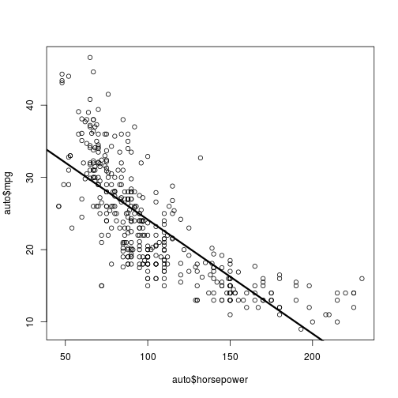

```r
plot(auto$horsepower, auto$mpg)
abline(fit, lwd=3)
```

Look at diagnostic plots.

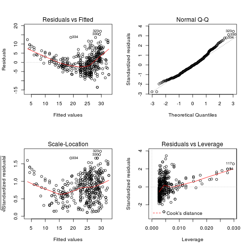

```r
par(mfrow = c(2,2))
plot(fit)
```

There seems to be hints of non-linearity in the data.

## Question 9

Remove the `name` column from data frame, and look at the scatter plot for all of the variables.

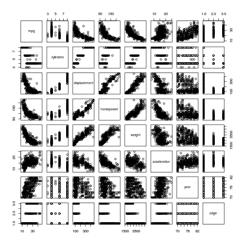

```r
auto$name = NULL
pairs(auto)
```

Look at the correlations between variables.

```r
cor(auto)
```

```
##                  mpg cylinders displacement horsepower  weight
## mpg           1.0000   -0.7776      -0.8051    -0.7784 -0.8322
## cylinders    -0.7776    1.0000       0.9508     0.8430  0.8975
## displacement -0.8051    0.9508       1.0000     0.8973  0.9330
## horsepower   -0.7784    0.8430       0.8973     1.0000  0.8645
## weight       -0.8322    0.8975       0.9330     0.8645  1.0000
## acceleration  0.4233   -0.5047      -0.5438    -0.6892 -0.4168
## year          0.5805   -0.3456      -0.3699    -0.4164 -0.3091
## origin        0.5652   -0.5689      -0.6145    -0.4552 -0.5850
##              acceleration    year  origin
## mpg                0.4233  0.5805  0.5652
## cylinders         -0.5047 -0.3456 -0.5689
## displacement      -0.5438 -0.3699 -0.6145
## horsepower        -0.6892 -0.4164 -0.4552
## weight            -0.4168 -0.3091 -0.5850
## acceleration       1.0000  0.2903  0.2127
## year               0.2903  1.0000  0.1815
## origin             0.2127  0.1815  1.0000
```

Fit multiple linear regression with all variables and look at diagnostic plots.

```r
fit = lm(mpg~., data=auto)
summary(fit)
```

```
##
## Call:
## lm(formula = mpg ~ ., data = auto)
##
## Residuals:
##    Min     1Q Median     3Q    Max
## -9.590 -2.157 -0.117  1.869 13.060
##
## Coefficients:
##               Estimate Std. Error t value Pr(>|t|)
## (Intercept)  -1.72e+01   4.64e+00   -3.71  0.00024 ***
## cylinders    -4.93e-01   3.23e-01   -1.53  0.12780
## displacement  1.99e-02   7.51e-03    2.65  0.00844 **
## horsepower   -1.70e-02   1.38e-02   -1.23  0.21963
## weight       -6.47e-03   6.52e-04   -9.93  < 2e-16 ***
## acceleration  8.06e-02   9.88e-02    0.82  0.41548
## year          7.51e-01   5.10e-02   14.73  < 2e-16 ***
## origin        1.43e+00   2.78e-01    5.13  4.7e-07 ***
## ---
## Signif. codes:  0 '***' 0.001 '**' 0.01 '*' 0.05 '.' 0.1 ' ' 1
##
## Residual standard error: 3.33 on 384 degrees of freedom
## Multiple R-squared: 0.821,   Adjusted R-squared: 0.818
## F-statistic:  252 on 7 and 384 DF,  p-value: <2e-16
```

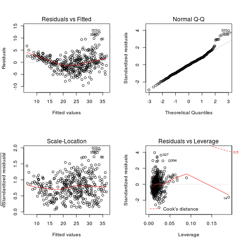

```r
par(mfrow = c(2,2))
plot(fit)
```

## Question 11

Generate data.

```r
set.seed(1)
x = rnorm(100)
y = 2*x + rnorm(100)
```

Regress `y` onto `x` and `x` onto `y` (without intercept term).

```r
f = lm(y~x+0)
f2 = lm(x~y+0)
```

Look at the fits. Note that t-values and \( R^2 \) are the same.

```r
summary(f)
```

```
##
## Call:
## lm(formula = y ~ x + 0)
##
## Residuals:
##    Min     1Q Median     3Q    Max
## -1.915 -0.647 -0.177  0.506  2.311
##
## Coefficients:
##   Estimate Std. Error t value Pr(>|t|)
## x    1.994      0.106    18.7   <2e-16 ***
## ---
## Signif. codes:  0 '***' 0.001 '**' 0.01 '*' 0.05 '.' 0.1 ' ' 1
##
## Residual standard error: 0.959 on 99 degrees of freedom
## Multiple R-squared: 0.78,    Adjusted R-squared: 0.778
## F-statistic:  351 on 1 and 99 DF,  p-value: <2e-16
```

```r
summary(f2)
```

```
##
## Call:
## lm(formula = x ~ y + 0)
##
## Residuals:
##    Min     1Q Median     3Q    Max
## -0.870 -0.237  0.103  0.286  0.894
##
## Coefficients:
##   Estimate Std. Error t value Pr(>|t|)
## y   0.3911     0.0209    18.7   <2e-16 ***
## ---
## Signif. codes:  0 '***' 0.001 '**' 0.01 '*' 0.05 '.' 0.1 ' ' 1
##
## Residual standard error: 0.425 on 99 degrees of freedom
## Multiple R-squared: 0.78,    Adjusted R-squared: 0.778
## F-statistic:  351 on 1 and 99 DF,  p-value: <2e-16
```

## Question 12

Coefficient estimates for regression of \( Y \) onto \( X \) and \( X \) onto \( Y \) are the same when \( \sum (x-\bar(x))^2 = \sum (y - \bar(x))^2 \). We can easily generate a set of observations where the coefficients estimates for the two directions are different.

```r
set.seed(1)
x = rnorm(100)
y = 2*x
f = lm(y~x+0)
f2 = lm(x~y+0)
f
```

```
##
## Call:
## lm(formula = y ~ x + 0)
##
## Coefficients:
## x
## 2
```

```r
f2
```

```
##
## Call:
## lm(formula = x ~ y + 0)
##
## Coefficients:
##   y
## 0.5
```

It is easy to generate a set of observations where the coefficient estimates for both directions are the same; we just need to ensure that sum of squares are the same for the input and output. An easy way to do this is to just permute the input data to create the output.

```r
y2 = sample(x = x, size = 100, replace = F)
f = lm(y2~x+0)
f2 = lm(x~y2+0)
f
```

```
##
## Call:
## lm(formula = y2 ~ x + 0)
##
## Coefficients:
##      x
## 0.0215
```

```r
f2
```

```
##
## Call:
## lm(formula = x ~ y2 + 0)
##
## Coefficients:
##     y2
## 0.0215
```

## Question 13

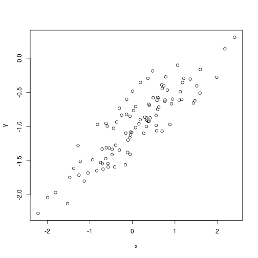

```r
set.seed(1)
x = rnorm(n = 100, sd = 1)
eps = rnorm(n = 100, sd = 0.25)
y = -1 + 0.5*x + eps
plot(x, y)
```

```r
fit = lm(y~x)
summary(fit)
```

```
##
## Call:
## lm(formula = y ~ x)
##
## Residuals:
##     Min      1Q  Median      3Q     Max
## -0.4692 -0.1534 -0.0349  0.1349  0.5865
##
## Coefficients:
##             Estimate Std. Error t value Pr(>|t|)
## (Intercept)  -1.0094     0.0242   -41.6   <2e-16 ***
## x             0.4997     0.0269    18.6   <2e-16 ***
## ---
## Signif. codes:  0 '***' 0.001 '**' 0.01 '*' 0.05 '.' 0.1 ' ' 1
##
## Residual standard error: 0.241 on 98 degrees of freedom
## Multiple R-squared: 0.778,   Adjusted R-squared: 0.776
## F-statistic:  344 on 1 and 98 DF,  p-value: <2e-16
```

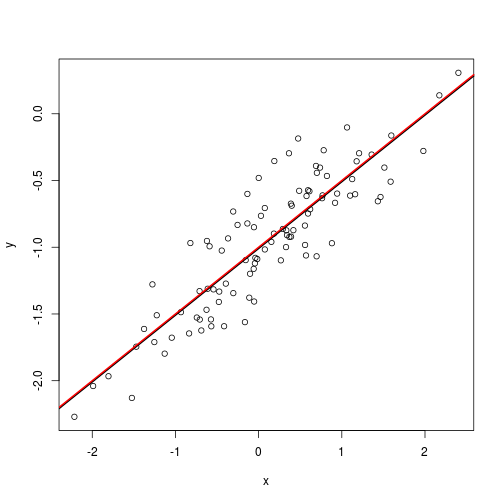

```r
plot(x, y)
abline(fit, lwd=2)
abline(coef = c(-1, 0.5), col='red', lwd=2)
```